# Project: Investigate a Dataset (TMDb Dataset)

- Introduction
- Data Wrangling
- Exploratory Data Analysis
- Conclusions

## Introduction

TMDb Movie data from Kaggle is chosen to investiage in the project. This data set contains information about 10,000 movies collected from The Movie Database (TMDb), including user ratings and revenue.

- Some columns, like cast and genres, contain multiple values separated by pipe (|) characters.
- The final two columns ending with _adj show the budget and revenue of the associated movie in terms of 2010 dollars, accounting for inflation over time.

## Questions

Here are the questions need to answer:

- Which movies were most and least profitable?
- What was the most profitable movie each year?
- Do movie budgets increase over time?
- What is the most profitable genre?

## Import Libraries

```python
import numpy as np
import pandas as pd
import seaborn as sns
import matplotlib.pyplot as plt
from scipy import stats
%matplotlib inline
```

```python
plt.style.use('fivethirtyeight')
plt.style.use('seaborn-poster')

# Format floats to show commas and two decimals
pd.options.display.float_format = "{0:,.2f}".format
```

## Data Wrangling

```python
df = pd.read_csv('tmdb-movies.csv')
df.head()
```

|  | id | imdb_id | popularity | budget | revenue | original_title | cast | homepage | director | tagline | ... | overview | runtime | genres | production_companies | release_date | vote_count | vote_average | release_year | budget_adj | revenue_adj |
| --- | --- | --- | --- | --- | --- | --- | --- | --- | --- | --- | --- | --- | --- | --- | --- | --- | --- | --- | --- | --- | --- |
| 0 | 135397 | tt0369610 | 32.99 | 150000000 | 1513528810 | Jurassic World | Chris Pratt\|Bryce Dallas Howard\|Irrfan Khan\|Vi... | http://www.jurassicworld.com/ | Colin Trevorrow | The park is open. | ... | Twenty-two years after the events of Jurassic ... | 124 | Action\|Adventure\|Science Fiction\|Thriller | Universal Studios\|Amblin Entertainment\|Legenda... | 6/9/15 | 5562 | 6.50 | 2015 | 137,999,939.28 | 1,392,445,892.52 |
| 1 | 76341 | tt1392190 | 28.42 | 150000000 | 378436354 | Mad Max: Fury Road | Tom Hardy\|Charlize Theron\|Hugh Keays-Byrne\|Nic... | http://www.madmaxmovie.com/ | George Miller | What a Lovely Day. | ... | An apocalyptic story set in the furthest reach... | 120 | Action\|Adventure\|Science Fiction\|Thriller | Village Roadshow Pictures\|Kennedy Miller Produ... | 5/13/15 | 6185 | 7.10 | 2015 | 137,999,939.28 | 348,161,292.49 |
| 2 | 262500 | tt2908446 | 13.11 | 110000000 | 295238201 | Insurgent | Shailene Woodley\|Theo James\|Kate Winslet\|Ansel... | http://www.thedivergentseries.movie/#insurgent | Robert Schwentke | One Choice Can Destroy You | ... | Beatrice Prior must confront her inner demons ... | 119 | Adventure\|Science Fiction\|Thriller | Summit Entertainment\|Mandeville Films\|Red Wago... | 3/18/15 | 2480 | 6.30 | 2015 | 101,199,955.47 | 271,619,025.41 |
| 3 | 140607 | tt2488496 | 11.17 | 200000000 | 2068178225 | Star Wars: The Force Awakens | Harrison Ford\|Mark Hamill\|Carrie Fisher\|Adam D... | http://www.starwars.com/films/star-wars-episod... | J.J. Abrams | Every generation has a story. | ... | Thirty years after defeating the Galactic Empi... | 136 | Action\|Adventure\|Science Fiction\|Fantasy | Lucasfilm\|Truenorth Productions\|Bad Robot | 12/15/15 | 5292 | 7.50 | 2015 | 183,999,919.04 | 1,902,723,129.80 |
| 4 | 168259 | tt2820852 | 9.34 | 190000000 | 1506249360 | Furious 7 | Vin Diesel\|Paul Walker\|Jason Statham\|Michelle ... | http://www.furious7.com/ | James Wan | Vengeance Hits Home | ... | Deckard Shaw seeks revenge against Dominic Tor... | 137 | Action\|Crime\|Thriller | Universal Pictures\|Original Film\|Media Rights ... | 4/1/15 | 2947 | 7.30 | 2015 | 174,799,923.09 | 1,385,748,801.47 |

5 rows × 21 columns

```python
df.shape
```

```
(10866, 21)
```

```python
df.dtypes
```

```
id                        int64
imdb_id                  object
popularity              float64
budget                    int64
revenue                   int64
original_title           object
cast                     object
homepage                 object
director                 object
tagline                  object
keywords                 object
overview                 object
runtime                   int64
genres                   object
production_companies     object
release_date             object
vote_count                int64
vote_average            float64
release_year              int64
budget_adj              float64
revenue_adj             float64
dtype: object
```

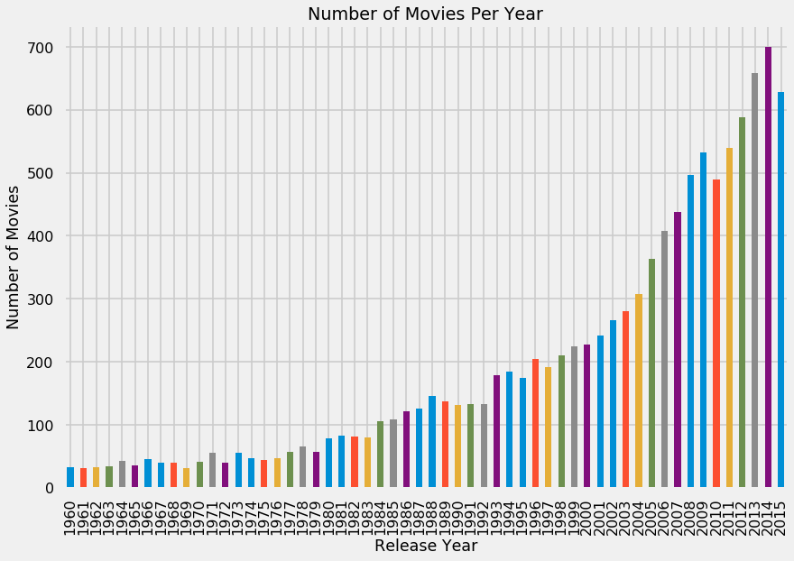

```python
#How many movies released by years?
df.groupby('release_year')['id'].count().plot.bar()
plt.xlabel('Release Year')
plt.ylabel('Number of Movies')
plt.title('Number of Movies Per Year')
plt.show()
```

### Data Cleaning

#### Eliminate duplicates

```python
sum(df.duplicated())
```

```
1
```

```python
df.drop_duplicates(inplace=True)
```

#### Convert datatypes

```python
df.dtypes.release_date
```

```
dtype('O')
```

```python
# Convert to a datetime
df['release_date'] = pd.to_datetime(df['release_date'])
```

```python
# Double check
df.dtypes.release_date
```

```
dtype('<M8[ns]')
```

#### Add columns

```python
# Calculate net income only if both budget_adj and revenue_adj are > 0
def income(row):
    if row['budget_adj'] > 0 and row['revenue_adj'] > 0:
        val = row['revenue_adj'] - row['budget_adj']
    else:
        val = float('NaN')
    return val
```

```python
# Add a net_income column
df['net_income'] = df.apply(income, axis=1)
df.head()
```

|  | id | imdb_id | popularity | budget | revenue | original_title | cast | homepage | director | tagline | ... | runtime | genres | production_companies | release_date | vote_count | vote_average | release_year | budget_adj | revenue_adj | net_income |
| --- | --- | --- | --- | --- | --- | --- | --- | --- | --- | --- | --- | --- | --- | --- | --- | --- | --- | --- | --- | --- | --- |
| 0 | 135397 | tt0369610 | 32.99 | 150000000 | 1513528810 | Jurassic World | Chris Pratt\|Bryce Dallas Howard\|Irrfan Khan\|Vi... | http://www.jurassicworld.com/ | Colin Trevorrow | The park is open. | ... | 124 | Action\|Adventure\|Science Fiction\|Thriller | Universal Studios\|Amblin Entertainment\|Legenda... | 2015-06-09 | 5562 | 6.50 | 2015 | 137,999,939.28 | 1,392,445,892.52 | 1,254,445,953.24 |
| 1 | 76341 | tt1392190 | 28.42 | 150000000 | 378436354 | Mad Max: Fury Road | Tom Hardy\|Charlize Theron\|Hugh Keays-Byrne\|Nic... | http://www.madmaxmovie.com/ | George Miller | What a Lovely Day. | ... | 120 | Action\|Adventure\|Science Fiction\|Thriller | Village Roadshow Pictures\|Kennedy Miller Produ... | 2015-05-13 | 6185 | 7.10 | 2015 | 137,999,939.28 | 348,161,292.49 | 210,161,353.21 |
| 2 | 262500 | tt2908446 | 13.11 | 110000000 | 295238201 | Insurgent | Shailene Woodley\|Theo James\|Kate Winslet\|Ansel... | http://www.thedivergentseries.movie/#insurgent | Robert Schwentke | One Choice Can Destroy You | ... | 119 | Adventure\|Science Fiction\|Thriller | Summit Entertainment\|Mandeville Films\|Red Wago... | 2015-03-18 | 2480 | 6.30 | 2015 | 101,199,955.47 | 271,619,025.41 | 170,419,069.94 |
| 3 | 140607 | tt2488496 | 11.17 | 200000000 | 2068178225 | Star Wars: The Force Awakens | Harrison Ford\|Mark Hamill\|Carrie Fisher\|Adam D... | http://www.starwars.com/films/star-wars-episod... | J.J. Abrams | Every generation has a story. | ... | 136 | Action\|Adventure\|Science Fiction\|Fantasy | Lucasfilm\|Truenorth Productions\|Bad Robot | 2015-12-15 | 5292 | 7.50 | 2015 | 183,999,919.04 | 1,902,723,129.80 | 1,718,723,210.76 |
| 4 | 168259 | tt2820852 | 9.34 | 190000000 | 1506249360 | Furious 7 | Vin Diesel\|Paul Walker\|Jason Statham\|Michelle ... | http://www.furious7.com/ | James Wan | Vengeance Hits Home | ... | 137 | Action\|Crime\|Thriller | Universal Pictures\|Original Film\|Media Rights ... | 2015-04-01 | 2947 | 7.30 | 2015 | 174,799,923.09 | 1,385,748,801.47 | 1,210,948,878.38 |

5 rows × 22 columns

```python
df.net_income.describe()
```

```
count           3,854.00
mean       92,824,697.22
std       194,071,459.74
min      -413,912,431.00
25%        -1,504,994.63
50%        27,370,641.16
75%       107,454,751.41
max     2,750,136,650.92
Name: net_income, dtype: float64
```

#### Normalize overloaded columns

```python
def splitDataFrameList(df, target_column, separator):
    row_accumulator = []

    def splitListToRows(row, separator):
        split_row = row[target_column].split(separator)
        for s in split_row:
            new_row = row.to_dict()
            new_row[target_column] = s
            row_accumulator.append(new_row)

    df.apply(splitListToRows, axis=1, args=(separator, ))
    new_df = pd.DataFrame(row_accumulator)
    return new_df
```

```python
# Split and flatten the cast and genres categories
df_flat = splitDataFrameList(df.dropna(), 'cast', '|')
df_flat = splitDataFrameList(df_flat.dropna(), 'genres', '|')
df_flat = splitDataFrameList(df_flat.dropna(), 'keywords', '|')
```

```python
df_flat.describe()
```

|  | budget | budget_adj | id | net_income | popularity | release_year | revenue | revenue_adj | runtime | vote_average | vote_count |
| --- | --- | --- | --- | --- | --- | --- | --- | --- | --- | --- | --- |
| count | 79,400.00 | 79,400.00 | 79,400.00 | 79,400.00 | 79,400.00 | 79,400.00 | 79,400.00 | 79,400.00 | 79,400.00 | 79,400.00 | 79,400.00 |
| mean | 60,724,919.60 | 63,757,724.78 | 49,444.64 | 172,223,733.42 | 2.03 | 2,006.67 | 208,570,350.20 | 235,981,458.19 | 111.02 | 6.30 | 1,110.75 |
| std | 59,801,738.44 | 59,404,434.38 | 70,693.56 | 295,085,244.58 | 2.46 | 8.49 | 281,825,273.88 | 326,061,177.81 | 19.43 | 0.80 | 1,377.22 |
| min | 1.00 | 0.97 | 11.00 | -413,912,431.00 | 0.01 | 1,961.00 | 43.00 | 43.00 | 63.00 | 2.20 | 10.00 |
| 25% | 17,000,000.00 | 19,387,960.85 | 4,464.00 | 5,387,689.10 | 0.76 | 2,005.00 | 31,670,620.00 | 34,084,779.31 | 97.00 | 5.80 | 228.00 |
| 50% | 40,000,000.00 | 43,622,911.92 | 17,979.00 | 60,073,390.00 | 1.32 | 2,009.00 | 101,371,017.00 | 110,662,825.91 | 108.00 | 6.30 | 560.00 |
| 75% | 85,000,000.00 | 91,941,878.45 | 60,308.00 | 210,161,353.21 | 2.49 | 2,011.00 | 284,600,000.00 | 320,834,306.77 | 122.00 | 6.90 | 1,527.00 |
| max | 425,000,000.00 | 425,000,000.00 | 333,348.00 | 2,750,136,650.92 | 32.99 | 2,015.00 | 2,781,505,847.00 | 2,827,123,750.41 | 201.00 | 8.30 | 9,767.00 |